# Globant - Data Scientist Test

Tatiana León

## Statement

In this dataset you have 3 different outputs:

1. No readmission;
2. A readmission in less than 30 days (this situation is not good, because maybe your treatment was not appropriate);
3. A readmission in more than 30 days (this one is not so good as well the last one, however, the reason could be the state of the patient.

Your task is either to classify a patient-hospital outcome or to cluster them aiming at finding patterns that give a distinct insight.

```r
library(dplyr)
library(class)
library(pROC)
library(dummies)
library(ROSE)
```

```r
library(sjPlot)
library(ggplot2)

setwd("C:/Users/Tatiana/Desktop/Programming")
```

## Reading and analyzing the data

We begin by reading and analyzing the data of the *Machine Learning UCI repository* in this link: https://archive.ics.uci.edu/ml/datasets/Diabetes+130-US+hospitals+for+years+1999-2008#

The zip contains two datasets:

1. diabetic_data
2. IDs_mapping

```r
data <- read.csv("diabetic_data.csv", sep = ",")
IDsMapp <- read.csv("IDs_mapping.csv", sep = ",")
head(data)
```

```
##   encounter_id patient_nbr            race gender     age weight
## 1      2278392     8222157       Caucasian Female  [0-10)      ?
## 2       149190    55629189       Caucasian Female [10-20)      ?
## 3        64410    86047875 AfricanAmerican Female [20-30)      ?
## 4       500364    82442376       Caucasian   Male [30-40)      ?
## 5        16680    42519267       Caucasian   Male [40-50)      ?
## 6        35754    82637451       Caucasian   Male [50-60)      ?
##   admission_type_id discharge_disposition_id admission_source_id
## 1                 6                       25                   1
## 2                 1                        1                   7
## 3                 1                        1                   7
## 4                 1                        1                   7
## 5                 1                        1                   7
## 6                 2                        1                   2
##   time_in_hospital payer_code        medical_specialty num_lab_procedures
```

[output cut: 55 more lines]

Now we will get some insights of the data, for example, the features, its values, its structure and the relevant variables.

```r
colnames(data)
```

```
##  [1] "encounter_id"             "patient_nbr"
##  [3] "race"                     "gender"
##  [5] "age"                      "weight"
##  [7] "admission_type_id"        "discharge_disposition_id"
##  [9] "admission_source_id"      "time_in_hospital"
## [11] "payer_code"               "medical_specialty"
## [13] "num_lab_procedures"       "num_procedures"
## [15] "num_medications"          "number_outpatient"
## [17] "number_emergency"         "number_inpatient"
## [19] "diag_1"                   "diag_2"
## [21] "diag_3"                   "number_diagnoses"
## [23] "max_glu_serum"            "A1Cresult"
## [25] "metformin"                "repaglinide"
## [27] "nateglinide"              "chlorpropamide"
## [29] "glimepiride"              "acetohexamide"
## [31] "glipizide"                "glyburide"
## [33] "tolbutamide"              "pioglitazone"
## [35] "rosiglitazone"            "acarbose"
## [37] "miglitol"                 "troglitazone"
## [39] "tolazamide"               "examide"
## [41] "citoglipton"              "insulin"
## [43] "glyburide.metformin"      "glipizide.metformin"
## [45] "glimepiride.pioglitazone" "metformin.rosiglitazone"
## [47] "metformin.pioglitazone"   "change"
## [49] "diabetesMed"              "readmitted"
```

```r
str(data)
```

```
## 'data.frame':    101766 obs. of  50 variables:
##  $ encounter_id            : int  2278392 149190 64410 500364 16680 35754 55842 63768 12522 15738 ...
##  $ patient_nbr             : int  8222157 55629189 86047875 82442376 42519267 82637451 84259809 114882984 48330783 63555939 ...
##  $ race                    : chr  "Caucasian" "Caucasian" "AfricanAmerican" "Caucasian" ...
##  $ gender                  : chr  "Female" "Female" "Female" "Male" ...
##  $ age                     : chr  "[0-10)" "[10-20)" "[20-30)" "[30-40)" ...
##  $ weight                  : chr  "?" "?" "?" "?" ...
##  $ admission_type_id       : int  6 1 1 1 1 2 3 1 2 3 ...
##  $ discharge_disposition_id: int  25 1 1 1 1 1 1 1 1 3 ...
##  $ admission_source_id     : int  1 7 7 7 7 2 2 7 4 4 ...
##  $ time_in_hospital        : int  1 3 2 2 1 3 4 5 13 12 ...
##  $ payer_code              : chr  "?" "?" "?" "?" ...
##  $ medical_specialty       : chr  "Pediatrics-Endocrinology" "?" "?" "?" ...
##  $ num_lab_procedures      : int  41 59 11 44 51 31 70 73 68 33 ...
##  $ num_procedures          : int  0 0 5 1 0 6 1 0 2 3 ...
```

[output cut: 36 more lines]

The first two columns encounter_id and patient_nbr are not relevant to this project, so we will remove them.

```r
data <- data %>% select(-encounter_id, -patient_nbr)
head(data)
```

```
##              race gender     age weight admission_type_id
## 1       Caucasian Female  [0-10)      ?                 6
## 2       Caucasian Female [10-20)      ?                 1
## 3 AfricanAmerican Female [20-30)      ?                 1
## 4       Caucasian   Male [30-40)      ?                 1
## 5       Caucasian   Male [40-50)      ?                 1
## 6       Caucasian   Male [50-60)      ?                 2
##   discharge_disposition_id admission_source_id time_in_hospital payer_code
## 1                       25                   1                1          ?
## 2                        1                   7                3          ?
## 3                        1                   7                2          ?
## 4                        1                   7                2          ?
## 5                        1                   7                1          ?
## 6                        1                   2                3          ?
##          medical_specialty num_lab_procedures num_procedures num_medications
```

[output cut: 55 more lines]

Let’s explore diag_1, diag_2 and diag_3 variables, as they have lots of values.

```r
diag1_table <- data %>% group_by(diag_1) %>% summarise(count = n(), prop = n()/nrow(data)) %>% arrange(desc(prop))
diag1_table
```

```
## # A tibble: 717 x 3
##    diag_1 count   prop
##    <chr>  <int>  <dbl>
##  1 428     6862 0.0674
##  2 414     6581 0.0647
##  3 786     4016 0.0395
##  4 410     3614 0.0355
##  5 486     3508 0.0345
##  6 427     2766 0.0272
##  7 491     2275 0.0224
##  8 715     2151 0.0211
##  9 682     2042 0.0201
## 10 434     2028 0.0199
## # ... with 707 more rows
```

```r
diag2_table <- data %>% group_by(diag_2) %>% summarise(count = n(), prop = n()/nrow(data)) %>% arrange(desc(prop))
diag2_table
```

```
## # A tibble: 749 x 3
##    diag_2 count   prop
##    <chr>  <int>  <dbl>
##  1 276     6752 0.0663
##  2 428     6662 0.0655
##  3 250     6071 0.0597
##  4 427     5036 0.0495
##  5 401     3736 0.0367
##  6 496     3305 0.0325
##  7 599     3288 0.0323
##  8 403     2823 0.0277
##  9 414     2650 0.0260
## 10 411     2566 0.0252
## # ... with 739 more rows
```

```r
diag3_table <- data %>% group_by(diag_3) %>% summarise(count = n(), prop = n()/nrow(data)) %>% arrange(desc(prop))
diag3_table
```

```
## # A tibble: 790 x 3
##    diag_3 count   prop
##    <chr>  <int>  <dbl>
##  1 250    11555 0.114
##  2 401     8289 0.0815
##  3 276     5175 0.0509
##  4 428     4577 0.0450
##  5 427     3955 0.0389
##  6 414     3664 0.0360
##  7 496     2605 0.0256
##  8 403     2357 0.0232
##  9 585     1992 0.0196
## 10 272     1969 0.0193
## # ... with 780 more rows
```

As they all have lots of values and none of them are significant, we will not add this variables to the model process.

```r
data <- data %>% select(-diag_1, -diag_2, -diag_3)
rm(diag1_table, diag2_table, diag3_table)
```

Let’s take a second look of the data.

```r
sapply(data, unique)
```

```
## $race
## [1] "Caucasian"       "AfricanAmerican" "?"               "Other"
## [5] "Asian"           "Hispanic"
##
## $gender
## [1] "Female"          "Male"            "Unknown/Invalid"
##
## $age
##  [1] "[0-10)"   "[10-20)"  "[20-30)"  "[30-40)"  "[40-50)"  "[50-60)"
##  [7] "[60-70)"  "[70-80)"  "[80-90)"  "[90-100)"
##
## $weight
##  [1] "?"         "[75-100)"  "[50-75)"   "[0-25)"    "[100-125)" "[25-50)"
##  [7] "[125-150)" "[175-200)" "[150-175)" ">200"
##
## $admission_type_id
## [1] 6 1 2 3 4 5 8 7
##
## $discharge_disposition_id
##  [1] 25  1  3  6  2  5 11  7 10  4 14 18  8 13 12 16 17 22 23  9 20 15 24 28 19
## [26] 27
##
## $admission_source_id
##  [1]  1  7  2  4  5  6 20  3 17  8  9 14 10 22 11 25 13
##
## $time_in_hospital
##  [1]  1  3  2  4  5 13 12  9  7 10  6 11  8 14
##
## $payer_code
##  [1] "?"  "MC" "MD" "HM" "UN" "BC" "SP" "CP" "SI" "DM" "CM" "CH" "PO" "WC" "OT"
## [16] "OG" "MP" "FR"
##
## $medical_specialty
##  [1] "Pediatrics-Endocrinology"
##  [2] "?"
##  [3] "InternalMedicine"
##  [4] "Family/GeneralPractice"
##  [5] "Cardiology"
##  [6] "Surgery-General"
##  [7] "Orthopedics"
```

[output cut: 166 more lines]

```
##
## $metformin.rosiglitazone
## [1] "No"     "Steady"
##
## $metformin.pioglitazone
## [1] "No"     "Steady"
##
## $change
## [1] "No" "Ch"
##
## $diabetesMed
## [1] "No"  "Yes"
##
## $readmitted
## [1] "NO"  ">30" "<30"
```

We have some “?” values in the missing data, so we will replace this values with the corresponding NA

```r
data <-na_if(data, "?")
str(data)
```

```
## 'data.frame':    101766 obs. of  45 variables:
##  $ race                    : chr  "Caucasian" "Caucasian" "AfricanAmerican" "Caucasian" ...
##  $ gender                  : chr  "Female" "Female" "Female" "Male" ...
##  $ age                     : chr  "[0-10)" "[10-20)" "[20-30)" "[30-40)" ...
##  $ weight                  : chr  NA NA NA NA ...
##  $ admission_type_id       : int  6 1 1 1 1 2 3 1 2 3 ...
##  $ discharge_disposition_id: int  25 1 1 1 1 1 1 1 1 3 ...
##  $ admission_source_id     : int  1 7 7 7 7 2 2 7 4 4 ...
##  $ time_in_hospital        : int  1 3 2 2 1 3 4 5 13 12 ...
##  $ payer_code              : chr  NA NA NA NA ...
##  $ medical_specialty       : chr  "Pediatrics-Endocrinology" NA NA NA ...
##  $ num_lab_procedures      : int  41 59 11 44 51 31 70 73 68 33 ...
##  $ num_procedures          : int  0 0 5 1 0 6 1 0 2 3 ...
##  $ num_medications         : int  1 18 13 16 8 16 21 12 28 18 ...
##  $ number_outpatient       : int  0 0 2 0 0 0 0 0 0 0 ...
```

[output cut: 31 more lines]

Some of the variables aren’t significant as they don’t have density, so we will remove them. These variables are: 1. examide 2. citoglipton 3. acetohexamide 4. troglitazone 5. tolbutamide 6. glimepiride.pioglitazone 7. metformin.rosiglitazone 8. metformin.pioglitazone 9. glipizide.metformin

```r
data <- data %>%
  select(-examide, -citoglipton, -acetohexamide, -troglitazone, -tolbutamide, -glimepiride.pioglitazone, -metformin.rosiglitazone, -metformin.pioglitazone, -glipizide.metformin)
sapply(data, unique)
```

```
## $race
## [1] "Caucasian"       "AfricanAmerican" NA                "Other"
## [5] "Asian"           "Hispanic"
##
## $gender
## [1] "Female"          "Male"            "Unknown/Invalid"
##
## $age
##  [1] "[0-10)"   "[10-20)"  "[20-30)"  "[30-40)"  "[40-50)"  "[50-60)"
##  [7] "[60-70)"  "[70-80)"  "[80-90)"  "[90-100)"
##
## $weight
##  [1] NA          "[75-100)"  "[50-75)"   "[0-25)"    "[100-125)" "[25-50)"
##  [7] "[125-150)" "[175-200)" "[150-175)" ">200"
##
## $admission_type_id
## [1] 6 1 2 3 4 5 8 7
##
## $discharge_disposition_id
##  [1] 25  1  3  6  2  5 11  7 10  4 14 18  8 13 12 16 17 22 23  9 20 15 24 28 19
## [26] 27
##
## $admission_source_id
##  [1]  1  7  2  4  5  6 20  3 17  8  9 14 10 22 11 25 13
##
## $time_in_hospital
##  [1]  1  3  2  4  5 13 12  9  7 10  6 11  8 14
##
## $payer_code
##  [1] NA   "MC" "MD" "HM" "UN" "BC" "SP" "CP" "SI" "DM" "CM" "CH" "PO" "WC" "OT"
## [16] "OG" "MP" "FR"
##
## $medical_specialty
##  [1] "Pediatrics-Endocrinology"
##  [2] NA
##  [3] "InternalMedicine"
##  [4] "Family/GeneralPractice"
##  [5] "Cardiology"
##  [6] "Surgery-General"
##  [7] "Orthopedics"
```

[output cut: 139 more lines]

```
##
## $insulin
## [1] "No"     "Up"     "Steady" "Down"
##
## $glyburide.metformin
## [1] "No"     "Steady" "Down"   "Up"
##
## $change
## [1] "No" "Ch"
##
## $diabetesMed
## [1] "No"  "Yes"
##
## $readmitted
## [1] "NO"  ">30" "<30"
```

Now we can convert the variables weight and age into numerical variables.

```r
data$weight <- ifelse(is.na(data$weight), "ND", data$weight)
data$weight <- as.factor(data$weight)
data$weight <- as.character(factor(data$weight,
                            levels = c("[0-25)", "[100-125)",  "[125-150)", "[150-175)", "[175-200)", "[25-50)" ,"[50-75)" , "[75-100)", ">200" , "ND"),
                            labels = c(25, 125,  150, 175, 200, 50 ,75 ,100, 200 , 0)),
                            stringsAsFactors=FALSE)
data$weight <- as.numeric(data$weight)

data$age <- ifelse(is.na(data$age), "ND", data$age)
data$age <- as.factor(data$age)
data$age <-  as.character(factor(data$age,
                          levels = c("[0-10)", "[10-20)", "[20-30)", "[30-40)", "[40-50)","[50-60)","[60-70)","[70-80)", "[80-90)", "[90-100)"),
                          labels = c(10, 20,  30,40, 50, 60 ,70 ,80, 90 ,100)),
                          stringsAsFactors=FALSE)
data$age <- as.numeric(data$age)
str(data)
```

```
## 'data.frame':    101766 obs. of  36 variables:
##  $ race                    : chr  "Caucasian" "Caucasian" "AfricanAmerican" "Caucasian" ...
##  $ gender                  : chr  "Female" "Female" "Female" "Male" ...
##  $ age                     : num  10 20 30 40 50 60 70 80 90 100 ...
##  $ weight                  : num  0 0 0 0 0 0 0 0 0 0 ...
##  $ admission_type_id       : int  6 1 1 1 1 2 3 1 2 3 ...
##  $ discharge_disposition_id: int  25 1 1 1 1 1 1 1 1 3 ...
##  $ admission_source_id     : int  1 7 7 7 7 2 2 7 4 4 ...
##  $ time_in_hospital        : int  1 3 2 2 1 3 4 5 13 12 ...
##  $ payer_code              : chr  NA NA NA NA ...
##  $ medical_specialty       : chr  "Pediatrics-Endocrinology" NA NA NA ...
##  $ num_lab_procedures      : int  41 59 11 44 51 31 70 73 68 33 ...
##  $ num_procedures          : int  0 0 5 1 0 6 1 0 2 3 ...
##  $ num_medications         : int  1 18 13 16 8 16 21 12 28 18 ...
##  $ number_outpatient       : int  0 0 2 0 0 0 0 0 0 0 ...
```

[output cut: 22 more lines]

The variables admission_type_id, discharge_disposition_id and admission_source_id, are categorical, although they seem numerical. We can see the meaning of each ID in the IDsMapp dataset.

Some of their values don’t need to be included in our model. We will remove the rows with discharge_disposition_id equal to 11, 19, 20, 21, as they mean expired status.

```r
data <- data[data$discharge_disposition_id!=11,]
data <- data[data$discharge_disposition_id!=19,]
data <- data[data$discharge_disposition_id!=20,]
data <- data[data$discharge_disposition_id!=21,]
rm(IDsMapp)
```

Now let’s define and explore our outcome vector.

```r
readm_t <- data %>%
  group_by(readmitted) %>%
  summarise(count = n(), prop = n()/nrow(data))
readm_t
```

```
## # A tibble: 3 x 3
##   readmitted count  prop
##   <chr>      <int> <dbl>
## 1 <30        11357 0.113
## 2 >30        35545 0.355
## 3 NO         53212 0.532
```

We would want to predict the readmitted cases in less than 30 days. So we will define our outcome variable as follows:

```r
y <- as.numeric(as.factor(data$readmitted))
y <- ifelse(y == 1,1,0)
rm(readm_t)
```

We can see that we have less than 50% of the data corresponding to the outcome 1, this implies that later we have to do some oversampling work.

Now, we will set-up all the data variables.

```r
data <- data %>% select(-readmitted)

#get NAs
apply(apply(data, 2, is.na), 2, sum)
```

```
##                     race                   gender                      age
##                     2239                        0                        0
##                   weight        admission_type_id discharge_disposition_id
##                        0                        0                        0
##      admission_source_id         time_in_hospital               payer_code
##                        0                        0                    39591
##        medical_specialty       num_lab_procedures           num_procedures
##                    49129                        0                        0
##          num_medications        number_outpatient         number_emergency
##                        0                        0                        0
##         number_inpatient         number_diagnoses            max_glu_serum
##                        0                        0                        0
##                A1Cresult                metformin              repaglinide
##                        0                        0                        0
##              nateglinide           chlorpropamide              glimepiride
##                        0                        0                        0
##                glipizide                glyburide             pioglitazone
##                        0                        0                        0
##            rosiglitazone                 acarbose                 miglitol
##                        0                        0                        0
##               tolazamide                  insulin      glyburide.metformin
##                        0                        0                        0
##                   change              diabetesMed
##                        0                        0
```

race, payer_code and medical_speciality are categorical variables, and they we NA values, we have to remove them by changing its value.

```r
data[is.na(data)] <- "ND"

#verify
apply(apply(data, 2, is.na), 2, sum)
```

```
##                     race                   gender                      age
##                        0                        0                        0
##                   weight        admission_type_id discharge_disposition_id
##                        0                        0                        0
##      admission_source_id         time_in_hospital               payer_code
##                        0                        0                        0
##        medical_specialty       num_lab_procedures           num_procedures
##                        0                        0                        0
##          num_medications        number_outpatient         number_emergency
##                        0                        0                        0
##         number_inpatient         number_diagnoses            max_glu_serum
##                        0                        0                        0
##                A1Cresult                metformin              repaglinide
##                        0                        0                        0
##              nateglinide           chlorpropamide              glimepiride
##                        0                        0                        0
##                glipizide                glyburide             pioglitazone
##                        0                        0                        0
##            rosiglitazone                 acarbose                 miglitol
##                        0                        0                        0
##               tolazamide                  insulin      glyburide.metformin
##                        0                        0                        0
##                   change              diabetesMed
##                        0                        0
```

Now, we will set-up the categorical and the numerical variables.

```r
cat_v <- colnames(data[,unlist(lapply(data,is.character))])
cat_v <- c(cat_v, "admission_type_id", "discharge_disposition_id", "admission_source_id")
cat_v
```

```
##  [1] "race"                     "gender"
##  [3] "payer_code"               "medical_specialty"
##  [5] "max_glu_serum"            "A1Cresult"
##  [7] "metformin"                "repaglinide"
##  [9] "nateglinide"              "chlorpropamide"
## [11] "glimepiride"              "glipizide"
## [13] "glyburide"                "pioglitazone"
## [15] "rosiglitazone"            "acarbose"
## [17] "miglitol"                 "tolazamide"
## [19] "insulin"                  "glyburide.metformin"
## [21] "change"                   "diabetesMed"
## [23] "admission_type_id"        "discharge_disposition_id"
## [25] "admission_source_id"
```

```r
##numerical variables
num_v <- colnames(data[,unlist(lapply(data,is.numeric))])
num_v <- num_v[-c(3,4,5)]
num_v
```

```
##  [1] "age"                "weight"             "time_in_hospital"
##  [4] "num_lab_procedures" "num_procedures"     "num_medications"
##  [7] "number_outpatient"  "number_emergency"   "number_inpatient"
## [10] "number_diagnoses"
```

From the categorical variables, we will reduce medical_specialty and payer_code.

```r
med_sp_t <- data %>% group_by(medical_specialty) %>% summarise(count = n(), prop = n()/nrow(data)) %>% arrange(desc(prop))
med_sp_t
```

```
## # A tibble: 73 x 3
##    medical_specialty          count   prop
##    <chr>                      <int>  <dbl>
##  1 ND                         49129 0.491
##  2 InternalMedicine           14328 0.143
##  3 Emergency/Trauma            7449 0.0744
##  4 Family/GeneralPractice      7302 0.0729
##  5 Cardiology                  5296 0.0529
##  6 Surgery-General             3068 0.0306
##  7 Nephrology                  1544 0.0154
##  8 Orthopedics                 1394 0.0139
##  9 Orthopedics-Reconstructive  1231 0.0123
## 10 Radiologist                 1129 0.0113
## # ... with 63 more rows
```

Lets reduce the 10% of the values into the category “Other”.

```r
med_spec_v <- c("ND", "InternalMedicine", "Emergency/Trauma", "Family/GeneralPractice", "Cardiology", "Surgery-General", "Nephrology", "Orthopedics" )
data  <-  data %>% mutate(medical_specialty = if_else(medical_specialty %in% med_spec_v, medical_specialty, "Other"))
rm(med_spec_v, med_sp_t)
```

```r
payer_t <- data %>% group_by(payer_code) %>% summarise(count = n(), prop = n()/nrow(data))%>% arrange(desc(prop))
payer_t
```

```
## # A tibble: 18 x 3
##    payer_code count       prop
##    <chr>      <int>      <dbl>
##  1 ND         39591 0.395
##  2 MC         31739 0.317
##  3 HM          6218 0.0621
##  4 SP          4956 0.0495
##  5 BC          4625 0.0462
##  6 MD          3492 0.0349
##  7 CP          2498 0.0250
##  8 UN          2425 0.0242
##  9 CM          1907 0.0190
## 10 OG          1023 0.0102
## 11 PO           586 0.00585
## 12 DM           546 0.00545
## 13 CH           144 0.00144
## 14 WC           135 0.00135
## 15 OT            94 0.000939
## 16 MP            79 0.000789
## 17 SI            55 0.000549
## 18 FR             1 0.00000999
```

```r
payer_v <- c("CP", "UN", "CM", "OG", "PO", "DM", "CH", "WC", "OT", "MP", "SI", "FR")
data  <-  data %>% mutate(payer_code = if_else(payer_code %in% payer_v, payer_code, "Other"))
rm(payer_v, payer_t)
```

Now we will convert the categorical variables in dummies, and then paste them to the numerical variables. This will be our preliminary final data.

```r
for (i in 1:25) {
  data[cat_v][,i] <- as.factor(data[cat_v][,i])
}

data_cat<-dummy.data.frame(data[cat_v])
```

[output not shown]

[output cut: 19 more lines]

[output not shown]

```r
data_num <- data[num_v]

data.d <- cbind(data_cat, data_num)
rm(data_cat, data_num, i, cat_v, num_v)

head(data.d)
```

```
##   raceAfricanAmerican raceAsian raceCaucasian raceHispanic raceND raceOther
## 1                   0         0             1            0      0         0
## 2                   0         0             1            0      0         0
## 3                   1         0             0            0      0         0
## 4                   0         0             1            0      0         0
## 5                   0         0             1            0      0         0
## 6                   0         0             1            0      0         0
##   genderFemale genderMale genderUnknown/Invalid payer_codeCH payer_codeCM
## 1            1          0                     0            0            0
## 2            1          0                     0            0            0
## 3            1          0                     0            0            0
## 4            0          1                     0            0            0
## 5            0          1                     0            0            0
## 6            0          1                     0            0            0
##   payer_codeCP payer_codeDM payer_codeFR payer_codeMP payer_codeOG payer_codeOT
```

[output cut: 279 more lines]

## Performing the model

First, we will normalize the variables of the dataset.

```r
normalize <- function(x)
{
  return((x- min(x)) /(max(x)-min(x)))
}
data.n <- as.data.frame(lapply(data.d[,], normalize))
```

As we said before, this dataset is imbalanced, so we have to oversampling its outcome values to get a better performance of the model.

```r
data.n <- cbind(data.n,y)
data.b <- ovun.sample(y~., data.n, method = "both", p = 0.5, seed = 42)
data.b <- as.data.frame(data.b$data)
```

Now, we will sample the rows.

```r
set.seed(42)
rows <- sample(nrow(data.b))
data.b <- data.b[rows,]
rm(rows)

y.b <- data.b$y
data.b <- data.b %>% select(-y)
```

Our final dataset to perform the model will be data.b.

#### k-Nearest Neighbor (knn)

With a piece of dataset, we will find the optimal k-value to train the knn model.

```r
data_test1 <- data.b[1:100,]
data_test2 <- data.b[101:200,]
y_test1 <-y.b[1:100]
y_test2 <- y.b[101:200]
```

```r
v <- c(0,0,0)
for (i in 1:floor(sqrt(100114*0.7))+1) {
  knn <- knn(data_test1, data_test2, cl=y_test1, k=i, prob = TRUE)
  accuracy = (table(knn ,y_test2)[1,1] + table(knn ,y_test2)[2,2])/sum(table(knn ,y_test2))
  r <- roc(y_test2, attributes(knn)$prob)
  v <- rbind(v, c(i, accuracy, as.numeric(r$auc)))
}
v <- as.data.frame(v)
colnames(v) <- c("k", "accuracy", "auc")
v
```

```
##         k accuracy       auc
## X       2     0.56 0.5375000
## X.1     3     0.58 0.5333333
## X.2     4     0.56 0.5206250
## X.3     5     0.60 0.6079167
## X.4     6     0.53 0.5668750
## X.5     7     0.60 0.5602083
## X.6     8     0.57 0.4729167
## X.7     9     0.54 0.5264583
## X.8    10     0.52 0.5533333
## X.9    11     0.60 0.5795833
## X.10   12     0.57 0.5820833
## X.11   13     0.59 0.6325000
## X.12   14     0.58 0.5706250
## X.13   15     0.55 0.5560417
## X.14   16     0.50 0.5847917
## X.15   17     0.53 0.5508333
## X.16   18     0.53 0.5410417
## X.17   19     0.57 0.5747917
## X.18   20     0.53 0.5795833
## X.19   21     0.56 0.5397917
## X.20   22     0.53 0.5456250
## X.21   23     0.50 0.5352083
## X.22   24     0.58 0.5581250
## X.23   25     0.57 0.5095833
## X.24   26     0.56 0.5243750
## X.25   27     0.62 0.4683333
## X.26   28     0.60 0.5093750
## X.27   29     0.56 0.5006250
## X.28   30     0.61 0.4797917
## X.29   31     0.60 0.5456250
## X.30   32     0.56 0.4243750
## X.31   33     0.59 0.5693750
## X.32   34     0.57 0.4443750
## X.33   35     0.59 0.4729167
## X.34   36     0.59 0.4656250
## X.35   37     0.57 0.4687500
## X.36   38     0.59 0.5152083
## X.37   39     0.59 0.5150000
## X.38   40     0.62 0.5414583
```

[output cut: 210 more lines]

```
## X.249 251     0.60 0.5000000
## X.250 252     0.60 0.5000000
## X.251 253     0.60 0.5000000
## X.252 254     0.60 0.5000000
## X.253 255     0.60 0.5000000
## X.254 256     0.60 0.5000000
## X.255 257     0.60 0.5000000
## X.256 258     0.60 0.5000000
## X.257 259     0.60 0.5000000
## X.258 260     0.60 0.5000000
## X.259 261     0.60 0.5000000
## X.260 262     0.60 0.5000000
## X.261 263     0.60 0.5000000
## X.262 264     0.60 0.5000000
## X.263 265     0.60 0.5000000
```

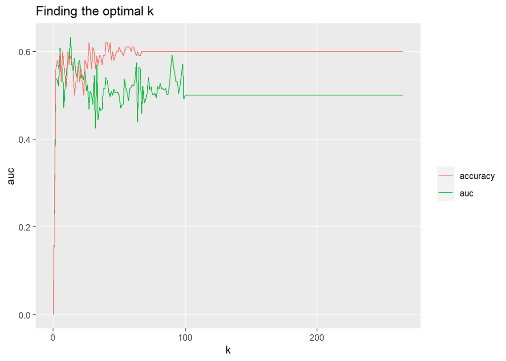

```r
ggplot(v,aes(x=k))+
  geom_line(aes(y=auc, col = "auc"))+
  geom_line(aes(y=accuracy, col = "accuracy"))+
  labs(title="Finding the optimal k")+
  scale_color_manual(name="",
                     values = c("auc"="#00ba38", "accuracy"="#f8766d")) +
  theme(panel.grid.minor = element_blank())
```

```r
rm(r, v, data_test1, data_test2, y_test1, y_test2, data.d, data.n, data)

data_train <- data.b[1:70080,]
data_test <- data.b[70081:nrow(data.b),]
y_train <-y.b[1:70080]
y_test <- y.b[70081:nrow(data.b)]

knn <- knn(data_train, data_test, cl=y_train, k=60, prob = TRUE)
```

## Evaluating the model

```r
roc(y_test, attributes(knn)$prob)
```

```
##
## Call:
## roc.default(response = y_test, predictor = attributes(knn)$prob)
##
## Data: attributes(knn)$prob in 15013 controls (y_test 0) < 15021 cases (y_test 1).
## Area under the curve: 0.5084
```

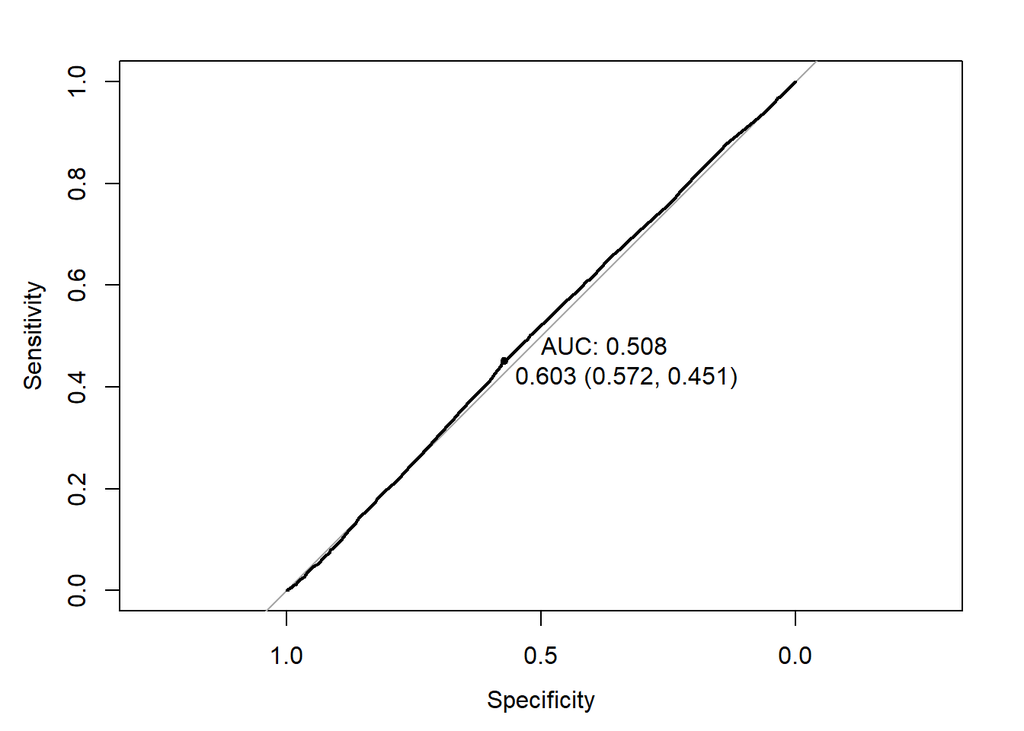

```r
plot(roc(y_test, attributes(knn)$prob),
     print.thres = T,
     print.auc=T)
```

```r
table(knn ,y_test)
```

```
##    y_test
## knn    0    1
##   0 8375 5346
##   1 6638 9675
```

```r
accuracy = (table(knn ,y_test)[1,1] + table(knn ,y_test)[2,2])/sum(table(knn ,y_test))
accuracy
```

```
## [1] 0.6009855
```

```r
recall = (table(knn ,y_test)[1,1])/(table(knn ,y_test)[1,1]+table(knn ,y_test)[2,1])
recall
```

```
## [1] 0.5578499
```

```r
precision = table(knn ,y_test)[1,1] /(table(knn ,y_test)[1,1]+table(knn ,y_test)[1,2])
precision
```

```
## [1] 0.6103783
```

```r
specificity = table(knn ,y_test)[2,2]/(table(knn ,y_test)[1,2]+table(knn ,y_test)[2,2])
specificity
```

```
## [1] 0.6440983
```

```r
prevalence = (table(knn ,y_test)[1,1]+table(knn ,y_test)[2,1])/sum(table(knn ,y_test))
prevalence
```

```
## [1] 0.4998668
```